# Lab Six: CNNs

Ayesh Madushanka Mahamada Kalpuwage

Flowers Data set

Here I tried to identify the five different flowers using CNN (daisy, rose, tulip, dandelion and sunflower)

I make this programe for wedding decorating company with fully automated. When you feed the model of flower colection into the machine, the robot start making the decorations without human support.

#### Q1-Choose and explain what metric(s) you will use to evaluate your algorithm’s performance.

I have five classes and those are nearly same size. False positive case from example, one place of the decoration doesn't include a Sunflower but our model selects it as Sunflower. In the other hand false negative, the decoration includes a Sunflower but our model selects as Rose. But in my business case if small mistake of both FN and FP do not make the situation too worst. I have balanced dataset and so I choose Accuracy as my metric.

```python
import tensorflow.keras as keras
from tensorflow.keras.models import Sequential
from tensorflow.keras.layers import Reshape, Input
from tensorflow.keras.layers import Dense, Dropout, Activation, Flatten
from tensorflow.keras.layers import Conv2D, MaxPooling2D
from tensorflow.keras.preprocessing.image import ImageDataGenerator
from tensorflow.keras.callbacks import EarlyStopping
from tensorflow.keras.regularizers import l2
from tensorflow.keras.layers import average
from tensorflow.keras.models import  Model
from sklearn import datasets, metrics
from sklearn.model_selection import train_test_split
import numpy as np
import tensorflow as tf
```

```python
try:

    import tensorflow as tf
    import cv2
    import os
    import pickle
    import numpy as np
    print("Library Loaded Successfully ..........")
except:
    print("Library not Found ! ")


class MasterImage(object):

    def __init__(self,PATH='', IMAGE_SIZE = 50):
        self.PATH = PATH
        self.IMAGE_SIZE = IMAGE_SIZE

        self.image_data = []
        self.x_data = []
        self.y_data = []
        self.CATEGORIES = []

        # This will get List of categories
        self.list_categories = []

    def get_categories(self):
        for path in os.listdir(self.PATH):
            if '.DS_Store' in path:
                pass
            else:
                self.list_categories.append(path)
        print("Found Categories ",self.list_categories,'\n')
        return self.list_categories

    def Process_Image(self):
        try:
            """
            Return Numpy array of image
            :return: X_Data, Y_Data
            """
            self.CATEGORIES = self.get_categories()
            for categories in self.CATEGORIES:                                                  # Iterate over categories

                train_folder_path = os.path.join(self.PATH, categories)                         # Folder Path
                class_index = self.CATEGORIES.index(categories)                                 # this will get index for classification

                for img in os.listdir(train_folder_path):                                       # This will iterate in the Folder
                    new_path = os.path.join(train_folder_path, img)                             # image Path

                    try:        # if any image is corrupted
                        image_data_temp = cv2.imread(new_path,cv2.IMREAD_GRAYSCALE)                 # Read Image as numbers
                        image_temp_resize = cv2.resize(image_data_temp,(self.IMAGE_SIZE,self.IMAGE_SIZE))
                        self.image_data.append([image_temp_resize,class_index])
                    except:
                        pass

            data = np.asanyarray(self.image_data)

            # Iterate over the Data
            for x in data:
                self.x_data.append(x[0])        # Get the X_Data
                self.y_data.append(x[1])        # get the label

            X_Data = np.asarray(self.x_data) / (255.0)      # Normalize Data
            Y_Data = np.asarray(self.y_data)

            # reshape x_Data

            X_Data = X_Data.reshape(-1, self.IMAGE_SIZE, self.IMAGE_SIZE, 1)

            return X_Data, Y_Data
        except:
            print("Failed to run Function Process Image ")

    def pickle_image(self):

        """
        :return: None Creates a Pickle Object of DataSet
        """
        # Call the Function and Get the Data
        X_Data,Y_Data = self.Process_Image()

        # Write the Entire Data into a Pickle File
        pickle_out = open('X_Data','wb')
        pickle.dump(X_Data, pickle_out)
        pickle_out.close()

        # Write the Y Label Data
        pickle_out = open('Y_Data', 'wb')
        pickle.dump(Y_Data, pickle_out)
        pickle_out.close()

        print("Pickled Image Successfully ")
        return X_Data,Y_Data

    def load_dataset(self):

        try:
            # Read the Data from Pickle Object
            X_Temp = open('X_Data','rb')
            X_Data = pickle.load(X_Temp)

            Y_Temp = open('Y_Data','rb')
            Y_Data = pickle.load(Y_Temp)

            print('Reading Dataset from PIckle Object')

            return X_Data,Y_Data

        except:
            print('Could not Found Pickle File ')
            print('Loading File and Dataset  ..........')

            X_Data,Y_Data = self.pickle_image()
            return X_Data,Y_Data
```

```
Library Loaded Successfully ..........
```

Above two codes are taken from: [1] Soumil Nitin Shah (2019) Smart Library to load image Dataset for Convolution Neural Network (Tensorflow/Keras)[https://github.com/soumilshah1995/Smart-Library-to-load-image-Dataset-for-Convolution-Neural-Network-Tensorflow-Keras-]

```python
if __name__ == "__main__":
    path = '/Users/ayeshmadushanka/Desktop/flowers'
    a = MasterImage(PATH=path,
                   IMAGE_SIZE=30)
    X_Data,Y_Data = a.load_dataset()
    print(X_Data.shape)
```

```
Reading Dataset from PIckle Object
(4317, 30, 30, 1)
```

#### Q2-Choose the method you will use for dividing your data into training and testing (i.e., are you using Stratified 10-fold cross validation? Shuffle splits? Why?)

It allows the training converge fast, prevents bias during the training and prevents the model from learning the order of the training.

```python
#X_Data= X_Data.reshape((X_Data.shape[0],1,8,8)) # reshape as images

# Split it into train / test subsets
X_train, X_test, y_train, y_test = train_test_split(X_Data, Y_Data, test_size=0.2)

# Split X_train again to create validation data
#X_train, X_val, y_train, y_val = train_test_split(X_train,y_train,test_size=0.2)

X_train.shape
```

```
(3453, 30, 30, 1)
```

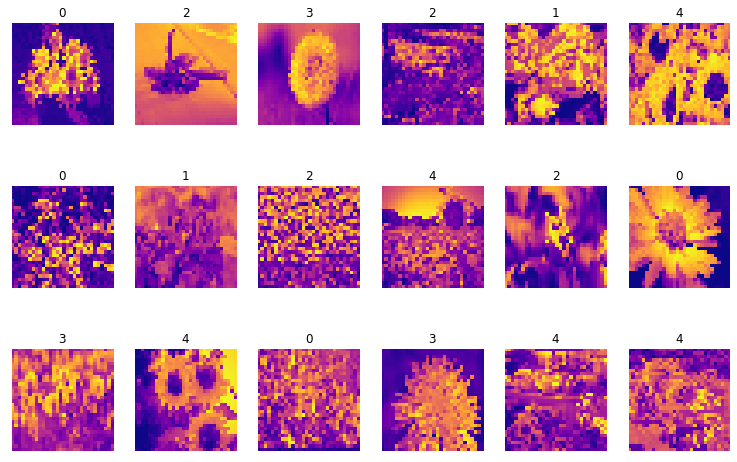

```python
# What do these images look like?
from matplotlib import pyplot as plt
%matplotlib inline
plt.style.use('ggplot')

# a helper plotting function
def plot_gallery(images, titles, h, w, n_row=3, n_col=6):
    """Helper function to plot a gallery of portraits"""
    plt.figure(figsize=(1.7 * n_col, 2.3 * n_row))
    plt.subplots_adjust(bottom=0, left=.01, right=.99, top=.90, hspace=.35)
    for i in range(n_row * n_col):
        plt.subplot(n_row, n_col, i + 1)
        plt.imshow(images[i].squeeze(), cmap=plt.cm.plasma)
        plt.title(titles[i], size=12)
        plt.xticks(())
        plt.yticks(())

plot_gallery(X_train, y_train, 8, 8)
```

```python
datagen = ImageDataGenerator(
    featurewise_center=False,
    samplewise_center=False,
    featurewise_std_normalization=False,
    samplewise_std_normalization=False,
    zca_whitening=False,
    rotation_range=60, # used, Int. Degree range for random rotations.
    width_shift_range=0.2, # used, Float (fraction of total width). Range for random horizontal shifts.
    height_shift_range=0.2, # used,  Float (fraction of total height). Range for random vertical shifts.
    shear_range=0., # Float. Shear Intensity (Shear angle in counter-clockwise direction as radians)
    zoom_range=0.3,
    channel_shift_range=0.,
    fill_mode='nearest',
    cval=0.2,
    horizontal_flip=True,
    vertical_flip=True,
    brightness_range=[0.4,1.5],
    rescale=None)


datagen.fit(X_train)

idx = 0
```

#### Q3-Setup the training to use data expansion in Keras. Explain why the chosen data expansion techniques are appropriate for your dataset.

These all the augmentations used to prevent overfit of the model.

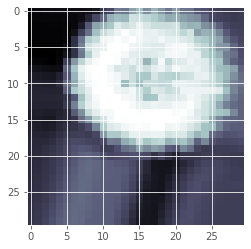

```python
tmps = datagen.flow(X_train, y_train, batch_size=1)

for tmp in tmps:
    plt.imshow(tmp[0].squeeze(),cmap='bone')
    #plt.title(labels[np.argmax(tmp[1])])
    break
```

```python
from sklearn import metrics as mt
from matplotlib import pyplot as plt
from skimage.io import imshow
import seaborn as sns
%matplotlib inline

labels = ['daisy', 'rose', 'tulip', 'dandelion', 'sunflower']
def summarize_net(net, X_test, y_test, title_text=''):
    plt.figure(figsize=(15,5))
    yhat = np.argmax(net.predict(X_test), axis=1)
    acc = mt.accuracy_score(y_test,yhat)
    cm = mt.confusion_matrix(y_test,yhat)
    cm = cm/np.sum(cm,axis=1)[:,np.newaxis]
    sns.heatmap(cm, annot=True, fmt='.2f', xticklabels=labels,yticklabels=labels)
    plt.title(title_text+'{:.4f}'.format(acc))
```

```python
NUM_CLASSES = 5
img_wh = 30

# Let's start by fixing the sizes, channels last
X_train = np.expand_dims(X_train.reshape((-1,img_wh,img_wh)), axis=3)
X_test = np.expand_dims(X_test.reshape((-1,img_wh,img_wh)), axis=3)
# the image data has been resized to (samples,image_rows,image_cols,image_channels)

# and one hot encoding the output values
y_train_ohe = keras.utils.to_categorical(y_train, NUM_CLASSES)
y_test_ohe = keras.utils.to_categorical(y_test, NUM_CLASSES)

print('New Shape: Rows: %d, image size: (%d,%d,%d)' % (X_train.shape[0], X_train.shape[1], X_train.shape[2], X_train.shape[3] ))
```

```
New Shape: Rows: 3453, image size: (30,30,1)
```

#### Q4-Create a convolutional neural network to use on your data using Keras. Investigate at least two different convolutional network architectures

# AlexNet

```python
%%time

cnn = Sequential()

# let's start with an AlexNet style convolutional phase
cnn.add(Conv2D(filters=32,
                input_shape = (img_wh,img_wh,1),
                kernel_size=(3,3),
                padding='same',
                activation='relu', data_format="channels_last")) # more compact syntax

# no max pool before next conv layer!!
cnn.add(Conv2D(filters=64,
                kernel_size=(3,3),
                padding='same',
                activation='relu')) # more compact syntax
cnn.add(MaxPooling2D(pool_size=(2, 2), data_format="channels_last"))


# add one layer on flattened output
cnn.add(Dropout(0.25)) # add some dropout for regularization after conv layers
cnn.add(Flatten())
cnn.add(Dense(128, activation='relu'))
cnn.add(Dropout(0.5)) # add some dropout for regularization, again!
cnn.add(Dense(NUM_CLASSES, activation='softmax'))

# Let's train the model
cnn.compile(loss='categorical_crossentropy', # 'categorical_crossentropy' 'mean_squared_error'
              optimizer='rmsprop', # 'adadelta' 'rmsprop'
              metrics=['accuracy'])

# the flow method yields batches of images indefinitely, with the given transformations
cnn.fit_generator(datagen.flow(X_train, y_train_ohe, batch_size=128),
                   steps_per_epoch=int(len(X_train)/128), # how many generators to go through per epoch
                   epochs=15, verbose=1,
                   validation_data=(X_test,y_test_ohe)
                  )
```

```
CPU times: user 20min 39s, sys: 13min 59s, total: 34min 39s
Wall time: 5min 42s
```

```
<tensorflow.python.keras.callbacks.History at 0x7fb9e2edf490>
```

# AlexNet with L2 regularization and some extra layers

```python
# what if we just want to use the validation data??
from tensorflow.keras.callbacks import EarlyStopping
from tensorflow.keras.regularizers import l2
l2_lambda = 0.0001

# Use Kaiming He to regularize ReLU layers: https://arxiv.org/pdf/1502.01852.pdf
# Use Glorot/Bengio for linear/sigmoid/softmax: http://proceedings.mlr.press/v9/glorot10a/glorot10a.pdf
cnn2 = Sequential()

cnn2.add(Conv2D(filters=32,
               input_shape = (img_wh,img_wh,1),
               kernel_size=(3,3),
               kernel_initializer='he_uniform',
               kernel_regularizer=l2(l2_lambda),
               padding='same',
               activation='relu',
               data_format="channels_last")) # more compact syntax

cnn2.add(Conv2D(filters=32,
               kernel_size=(3,3),
               kernel_initializer='he_uniform',
               kernel_regularizer=l2(l2_lambda),
               padding='same',
               activation='relu',data_format="channels_last"))
cnn2.add(MaxPooling2D(pool_size=(2, 2), data_format="channels_last"))

cnn2.add(Conv2D(filters=64,
               input_shape = (img_wh,img_wh,1),
               kernel_size=(3,3),
               kernel_initializer='he_uniform',
               kernel_regularizer=l2(l2_lambda),
               padding='same',
               activation='relu',data_format="channels_last")) # more compact syntax

cnn2.add(Conv2D(filters=64,
               kernel_size=(3,3),
               kernel_initializer='he_uniform',
               kernel_regularizer=l2(l2_lambda),
               padding='same',
               activation='relu'))
cnn2.add(MaxPooling2D(pool_size=(2, 2), data_format="channels_last"))

cnn2.add(Conv2D(filters=128,
               input_shape = (img_wh,img_wh,1),
               kernel_size=(3,3),
               kernel_initializer='he_uniform',
               kernel_regularizer=l2(l2_lambda),
               padding='same',
               activation='relu',data_format="channels_last")) # more compact syntax

cnn2.add(Conv2D(filters=128,
               kernel_size=(3,3),
               kernel_initializer='he_uniform',
               kernel_regularizer=l2(l2_lambda),
               padding='same',
               activation='relu',data_format="channels_last"))


# add one layer on flattened output

cnn2.add(Flatten())
cnn2.add(Dropout(0.25)) # add some dropout for regularization after conv layers
cnn2.add(Dense(128,
              activation='relu',
              kernel_initializer='he_uniform',
              kernel_regularizer=l2(l2_lambda)
       ))
cnn2.add(Dropout(0.5)) # add some dropout for regularization, again!
cnn2.add(Dense(NUM_CLASSES,
              activation='softmax',
              kernel_initializer='glorot_uniform',
              kernel_regularizer=l2(l2_lambda)
             ))

# Let's train the model
cnn2.compile(loss='categorical_crossentropy', # 'categorical_crossentropy' 'mean_squared_error'
              optimizer='rmsprop', # 'adadelta' 'rmsprop'
              metrics=['accuracy'])

# the flow method yields batches of images indefinitely, with the given transofmrations
cnn2.fit_generator(datagen.flow(X_train, y_train_ohe, batch_size=128),
                  steps_per_epoch=int(len(X_train)/128), # how many generators to go through per epoch
                  epochs=50, verbose=1,
                  validation_data=(X_test,y_test_ohe),
                  callbacks=[EarlyStopping(monitor='val_loss', patience=2)]
                 )
```

```
<tensorflow.python.keras.callbacks.History at 0x7fb9e56905d0>
```

# ResNet

```python
%%time


# We will also use ReLU where approriate and drop out
from tensorflow.keras.layers import Add, Input
from tensorflow.keras.layers import average, concatenate
from tensorflow.keras.models import Model

input_holder = Input(shape=(img_wh, img_wh, 1))

# start with a conv layer
x = Conv2D(filters=32,
               input_shape = (img_wh,img_wh,1),
               kernel_size=(3,3),
               kernel_initializer='he_uniform',
               kernel_regularizer=l2(l2_lambda),
               padding='same',
               activation='relu',
               data_format="channels_last")(input_holder)

x = MaxPooling2D(pool_size=(2, 2), data_format="channels_last")(x)

x = Conv2D(filters=32,
               kernel_size=(3,3),
               kernel_initializer='he_uniform',
               kernel_regularizer=l2(l2_lambda),
               padding='same',
               activation='relu',
               data_format="channels_last")(x)

x_split = MaxPooling2D(pool_size=(2, 2), data_format="channels_last")(x)

x = Conv2D(filters=64,
               kernel_size=(1,1),
               kernel_initializer='he_uniform',
               kernel_regularizer=l2(l2_lambda),
               padding='same',
               activation='relu',
               data_format="channels_last")(x_split)

x = Conv2D(filters=64,
               kernel_size=(3,3),
               kernel_initializer='he_uniform',
               kernel_regularizer=l2(l2_lambda),
               padding='same',
               activation='relu',
               data_format="channels_last")(x)

x = Conv2D(filters=32,
               kernel_size=(1,1),
               kernel_initializer='he_uniform',
               kernel_regularizer=l2(l2_lambda),
               padding='same',
               activation='relu',
               data_format="channels_last")(x)

# now add back in the split layer, x_split (residual added in)
x = Add()([x, x_split])
x = Activation("relu")(x)

x = MaxPooling2D(pool_size=(2, 2), data_format="channels_last")(x)

x = Flatten()(x)
x = Dropout(0.25)(x)
x = Dense(256)(x)
x = Activation("relu")(x)
x = Dropout(0.5)(x)
x = Dense(NUM_CLASSES)(x)
x = Activation('softmax')(x)

resnet = Model(inputs=input_holder,outputs=x)

resnet.summary()
```

```
Model: "model_1"
__________________________________________________________________________________________________
Layer (type)                    Output Shape         Param #     Connected to
==================================================================================================
input_2 (InputLayer)            [(None, 30, 30, 1)]  0
__________________________________________________________________________________________________
conv2d_18 (Conv2D)              (None, 30, 30, 32)   320         input_2[0][0]
__________________________________________________________________________________________________
max_pooling2d_9 (MaxPooling2D)  (None, 15, 15, 32)   0           conv2d_18[0][0]
__________________________________________________________________________________________________
conv2d_19 (Conv2D)              (None, 15, 15, 32)   9248        max_pooling2d_9[0][0]
__________________________________________________________________________________________________
max_pooling2d_10 (MaxPooling2D) (None, 7, 7, 32)     0           conv2d_19[0][0]
__________________________________________________________________________________________________
conv2d_20 (Conv2D)              (None, 7, 7, 64)     2112        max_pooling2d_10[0][0]
__________________________________________________________________________________________________
conv2d_21 (Conv2D)              (None, 7, 7, 64)     36928       conv2d_20[0][0]
__________________________________________________________________________________________________
conv2d_22 (Conv2D)              (None, 7, 7, 32)     2080        conv2d_21[0][0]
__________________________________________________________________________________________________
add (Add)                       (None, 7, 7, 32)     0           conv2d_22[0][0]
                                                                 max_pooling2d_10[0][0]
__________________________________________________________________________________________________
activation (Activation)         (None, 7, 7, 32)     0           add[0][0]
__________________________________________________________________________________________________
max_pooling2d_11 (MaxPooling2D) (None, 3, 3, 32)     0           activation[0][0]
__________________________________________________________________________________________________
flatten_5 (Flatten)             (None, 288)          0           max_pooling2d_11[0][0]
__________________________________________________________________________________________________
dropout_7 (Dropout)             (None, 288)          0           flatten_5[0][0]
__________________________________________________________________________________________________
dense_11 (Dense)                (None, 256)          73984       dropout_7[0][0]
__________________________________________________________________________________________________
activation_1 (Activation)       (None, 256)          0           dense_11[0][0]
__________________________________________________________________________________________________
dropout_8 (Dropout)             (None, 256)          0           activation_1[0][0]
__________________________________________________________________________________________________
dense_12 (Dense)                (None, 5)            1285        dropout_8[0][0]
__________________________________________________________________________________________________
activation_2 (Activation)       (None, 5)            0           dense_12[0][0]
==================================================================================================
Total params: 125,957
Trainable params: 125,957
Non-trainable params: 0
__________________________________________________________________________________________________
CPU times: user 82.8 ms, sys: 1.95 ms, total: 84.8 ms
Wall time: 74.6 ms
```

```python
resnet.compile(loss='categorical_crossentropy', # 'categorical_crossentropy' 'mean_squared_error'
                optimizer='adam', # 'adadelta' 'rmsprop'
                metrics=['accuracy'])

# the flow method yields batches of images indefinitely, with the given transofmrations
# resnet.fit_generator(datagen.flow(X_train, y_train_ohe, batch_size=128),
#                       steps_per_epoch=int(len(X_train)/128), # how many generators to go through per epoch
#                       epochs=50, verbose=1,
#                       validation_data=(X_test,y_test_ohe),
#                       callbacks=[EarlyStopping(monitor='val_loss', patience=4)]
#                      )

resnet.fit(X_train, y_train_ohe, batch_size=128,
                      epochs=50, verbose=1,
                      validation_data=(X_test,y_test_ohe),
                      callbacks=[EarlyStopping(monitor='val_loss', patience=4)]
                     )
```

```
Train on 3453 samples, validate on 864 samples
```

```
<tensorflow.python.keras.callbacks.History at 0x7fb9e3ca7a50>
```